# Scraping table data

Pablo Barbera and Akitaka Matsuo

October 25, 2018

### Scraping web data in table format

We will start by loading the `rvest` package, which will help us scrape data from the web.

```r
library(rvest)
```

The goal of this exercise is to scrape the number of new social security number holders by year in the US, and then clean it so that we can generate a plot showing the evolution in this variable over time.

The first step is to read the html code from the website we want to scrape, using the `read_html()` function. If we want to see the html in text format, we can then use `html_text()`.

```r
url <- "https://www.ssa.gov/oact/babynames/numberUSbirths.html"
# reading the html code into memory
html_content <- read_html(url)
# not very informative
print(html_content)
```

```
## {xml_document}
## <html class="no-js" lang="en">
## [1] <head>\n<meta http-equiv="Content-Type" content="text/html; charset= ...
## [2] <body class="oact-sidebar-rows">\r\n<!-- PAGE CONTAINER -->\r\n<div  ...
```

```r
# first 1000 characters
substr(html_content, 1, 1000)
```

```
## [1] "<!DOCTYPE html>\n<html class=\"no-js\" lang=\"en\">\n<head>\n<meta http-equiv=\"Content-Type\" content=\"text/html; charset=UTF-8\">\n<!-- REQUIRED META INFORMATION --><meta charset=\"UTF-8\">\n<meta http-equiv=\"X-UA-Compatible\" content=\"IE=Edge,chrome=1\">\n<meta name=\"viewport\" conten…
```

To extract all the tables in the html code automatically, we use `html_table()`. Note that it returns a list of data frames, so in order to work with this dataset, we will have to subset the second element of this list.

```r
tab <- html_table(html_content, fill = TRUE)
# check the tables
length(tab)
```

```
## [1] 2
```

```r
str(tab)
```

```
## List of 2
##  $ :'data.frame':    140 obs. of  558 variables:
##   ..$ X1  : chr [1:140] "Popular Baby Names\r\n    \r\n      Background information\r\n      Beyond the top 1000 names\r\n      Social S"| __truncated__ "Year ofbirth" "1880" "1881" ...
##   ..$ X2  : chr [1:140] "Our popular name data come from applications for Social Security cards. The table \r\n   below shows the number"| __truncated__ "Male" "118,400" "108,282" ...
##   ..$ X3  : chr [1:140] "Year ofbirth" "Female" "97,605" "98,855" ...
##   ..$ X4  : chr [1:140] "Male" "Total" "216,005" "207,137" ...
##   ..$ X5  : chr [1:140] "Female" NA NA NA ...
##   ..$ X6  : chr [1:140] "Total" NA NA NA ...
##   ..$ X7  : int [1:140] 1880 NA NA NA NA NA NA NA NA NA ...
##   ..$ X8  : chr [1:140] "118,400" NA NA NA ...
##   ..$ X9  : chr [1:140] "97,605" NA NA NA ...
##   ..$ X10 : chr [1:140] "216,005" NA NA NA ...
##   ..$ X11 : int [1:140] 1881 NA NA NA NA NA NA NA NA NA ...
##   ..$ X12 : chr [1:140] "108,282" NA NA NA ...
##   ..$ X13 : chr [1:140] "98,855" NA NA NA ...
##   ..$ X14 : chr [1:140] "207,137" NA NA NA ...
##   ..$ X15 : int [1:140] 1882 NA NA NA NA NA NA NA NA NA ...
##   ..$ X16 : chr [1:140] "122,031" NA NA NA ...
##   ..$ X17 : chr [1:140] "115,695" NA NA NA ...
##   ..$ X18 : chr [1:140] "237,726" NA NA NA ...
##   ..$ X19 : int [1:140] 1883 NA NA NA NA NA NA NA NA NA ...
##   ..$ X20 : chr [1:140] "112,477" NA NA NA ...
##   ..$ X21 : chr [1:140] "120,059" NA NA NA ...
##   ..$ X22 : chr [1:140] "232,536" NA NA NA ...
##   ..$ X23 : int [1:140] 1884 NA NA NA NA NA NA NA NA NA ...
##   ..$ X24 : chr [1:140] "122,738" NA NA NA ...
##   ..$ X25 : chr [1:140] "137,586" NA NA NA ...
##   ..$ X26 : chr [1:140] "260,324" NA NA NA ...
##   ..$ X27 : int [1:140] 1885 NA NA NA NA NA NA NA NA NA ...
##   ..$ X28 : chr [1:140] "115,945" NA NA NA ...
##   ..$ X29 : chr [1:140] "141,948" NA NA NA ...
##   ..$ X30 : chr [1:140] "257,893" NA NA NA ...
##   ..$ X31 : int [1:140] 1886 NA NA NA NA NA NA NA NA NA ...
##   ..$ X32 : chr [1:140] "119,041" NA NA NA ...
##   ..$ X33 : chr [1:140] "153,735" NA NA NA ...
##   ..$ X34 : chr [1:140] "272,776" NA NA NA ...
##   ..$ X35 : int [1:140] 1887 NA NA NA NA NA NA NA NA NA ...
##   ..$ X36 : chr [1:140] "109,313" NA NA NA ...
##   ..$ X37 : chr [1:140] "155,422" NA NA NA ...
##   ..$ X38 : chr [1:140] "264,735" NA NA NA ...
```

[output cut: 52 more lines]

```
##   ..$ X91 : int [1:140] 1901 NA NA NA NA NA NA NA NA NA ...
##   ..$ X92 : chr [1:140] "115,595" NA NA NA ...
##   ..$ X93 : chr [1:140] "254,229" NA NA NA ...
##   ..$ X94 : chr [1:140] "369,824" NA NA NA ...
##   ..$ X95 : int [1:140] 1902 NA NA NA NA NA NA NA NA NA ...
##   ..$ X96 : chr [1:140] "132,750" NA NA NA ...
##   ..$ X97 : chr [1:140] "280,334" NA NA NA ...
##   ..$ X98 : chr [1:140] "413,084" NA NA NA ...
##   ..$ X99 : int [1:140] 1903 NA NA NA NA NA NA NA NA NA ...
##   .. [list output truncated]
##  $ :'data.frame':    138 obs. of  4 variables:
##   ..$ Year ofbirth: int [1:138] 1880 1881 1882 1883 1884 1885 1886 1887 1888 1889 ...
##   ..$ Male        : chr [1:138] "118,400" "108,282" "122,031" "112,477" ...
##   ..$ Female      : chr [1:138] "97,605" "98,855" "115,695" "120,059" ...
##   ..$ Total       : chr [1:138] "216,005" "207,137" "237,726" "232,536" ...
```

```r
# use the population tables
data_pop <- tab[[2]]
```

Now let’s clean the data so that we can use it for our analysis. We need to convert the population values into a numeric format, which requires deleting the commas. We will also change the variable names so that it’s easier to work with them.

```r
## remove commas and then make variable numeric
data_pop$Male <-  as.numeric(gsub(",", "", data_pop$Male))
data_pop$Female <- as.numeric(gsub(",", "", data_pop$Female))
data_pop$Total <- as.numeric(gsub(",", "", data_pop$Total))

## rename variables
names(data_pop) <- c('year', 'male', 'female', 'total')
```

And now we can plot to see how the number of people applying for a Social Security Number in the US has increased over time.

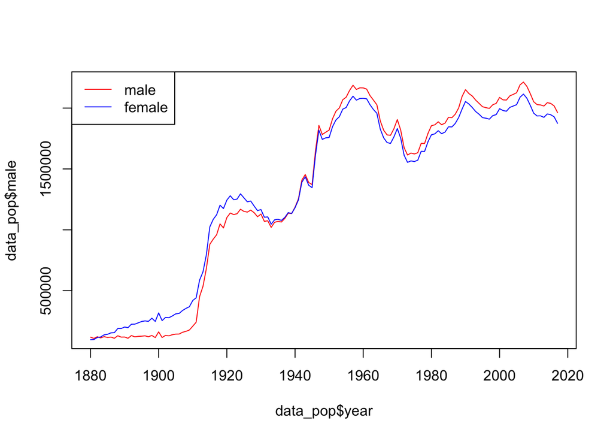

```r
plot(data_pop$year, data_pop$male, type = 'l', col = 'red')
lines(data_pop$year, data_pop$female, col = 'blue')
legend(x = 'topleft', col = c("red", "blue"), lty = 1, legend = c("male", "female"))

## or ggplot
## ggplot requires the data to be in tidy shape. for that we use
## melt() function in reshape2
library(ggplot2)
```

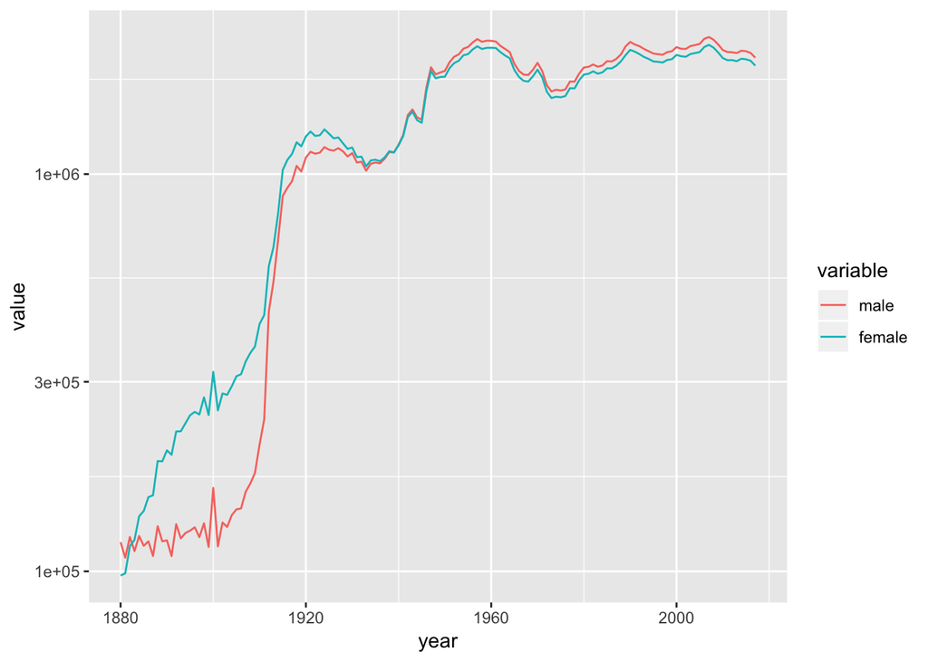

```r
data_pop_melt <- reshape2::melt(data_pop[, 1:3], id.vars = "year")
ggplot(data_pop_melt) + aes(x = year, y = value, group = variable, colour = variable) +
  geom_line() + scale_y_log10()
```

### Scraping web data in table format: a more advanced example

When there are multiple tables on the website, scraping them becomes a bit more complicated. Let’s work through a common case scenario: scraping a table from Wikipedia with a list of the most populated cities in the United States.

```r
url <- 'https://en.wikipedia.org/wiki/List_of_United_States_cities_by_population'
html <- read_html(url)
tables <- html_table(html, fill=TRUE)
length(tables)
```

```
## [1] 12
```

The function now returns 12 different tables. I had to use the option `fill=TRUE` because some of the tables appear to have incomplete rows.

In this case, identifying the part of the html code that contains the table is a better approach. To do so, let’s take a look at the source code of the website. In Google Chrome, go to *View* > *Developer* > *View Source*. All browsers should have similar options to view the source code of a website.

In the source code, search for the text of the page (e.g. *2017 rank*). Right above it you will see: `<table class="wikitable sortable"...">`. This is the CSS selector that contains the table. (You can also find this information by right-clicking anywhere on the table, and choosing *Inspect*).

Now that we now what we’re looking for, let’s use `html_nodes()` to identify all the elements of the page that have that CSS class. (Note that we need to use a dot before the name of the class to indicate it’s CSS.)

```r
wiki <- html_nodes(html, '.wikitable')
length(wiki)
```

```
## [1] 7
```

```r
data_pop <- html_table(wiki[[2]])
str(data_pop)
```

```
## 'data.frame':    311 obs. of  11 variables:
##  $ 2017rank               : int  1 2 3 4 5 6 7 8 9 10 ...
##  $ City                   : chr  "New York[6]" "Los Angeles" "Chicago" "Houston[7]" ...
##  $ State[5]               : chr  "New York" "California" "Illinois" "Texas" ...
##  $ 2017estimate           : chr  "8,622,698" "3,999,759" "2,716,450" "2,312,717" ...
##  $ 2010Census             : chr  "8,175,133" "3,792,621" "2,695,598" "2,100,263" ...
##  $ Change                 : chr  "+5.47%" "+5.46%" "+0.77%" "+10.12%" ...
##  $ 2016 land area         : chr  "301.5 sq mi" "468.7 sq mi" "227.3 sq mi" "637.5 sq mi" ...
##  $ 2016 land area         : chr  "780.9 km2" "1,213.9 km2" "588.7 km2" "1,651.1 km2" ...
##  $ 2016 population density: chr  "28,317/sq mi" "8,484/sq mi" "11,900/sq mi" "3,613/sq mi" ...
##  $ 2016 population density: chr  "10,933/km2" "3,276/km2" "4,600/km2" "1,395/km2" ...
##  $ Location               : chr  "40°39′49″N 73°56′19″W / 40.6635°N 73.9387°W / 40.6635; -73.9387 (1 New York City)" "34°01′10″N 118°24′39″W / 34.0194°N 118.4108°W / 34.0194; -118.4108 (2 Los Angeles)" "41°50′15″N 87°40′54″W / 41.8376°N 87.6818°W / 41.8376; -87.6818 (3 Chicago)" "29°47′12″N 95°23…
```

As in the previous case, we still need to clean the data before we can use it. For this particular example, let’s see if this dataset provides evidence in support of [Zipf’s law for population ranks](https://en.wikipedia.org/wiki/Zipf%27s_law).

We’ll use regular expressions to remove endnotes and commas in the population numbers, and clean the variable names. (We’ll come back to this later in the course.)

```r
data_pop$city_name <- gsub('\\[.*\\]', '', data_pop$City)
data_pop$population <- data_pop[,"2017estimate"]
data_pop$population <- as.numeric(gsub(",", "", data_pop$population))
data_pop$rank <- data_pop[,"2017rank"]
data_pop <- data_pop[,c("rank", "population", "city_name")]
```

Now we’re ready to generate the figure:

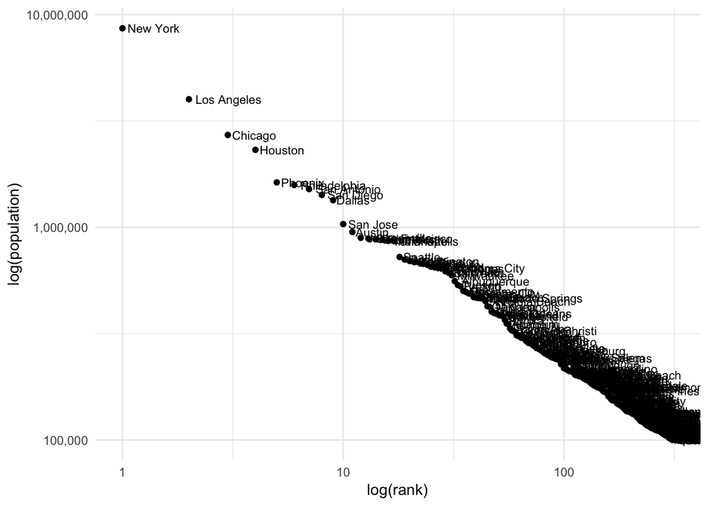

```r
library(ggplot2)
p <- ggplot(data_pop, aes(x=rank, y=population, label=city_name))
pq <- p + geom_point() + geom_text(hjust=-.1, size=3) +
    scale_x_log10("log(rank)") +
  scale_y_log10("log(population)", labels=scales::comma) +
  theme_minimal()
pq
```

We can also check if this distribution follows Zipf’s law estimating a log-log regression.

```r
summary(lm(log(rank) ~ log(population), data = data_pop))
```

```
##
## Call:
## lm(formula = log(rank) ~ log(population), data = data_pop)
##
## Residuals:
##      Min       1Q   Median       3Q      Max
## -0.29958 -0.02057 -0.00316  0.02011  0.36881
##
## Coefficients:
##                  Estimate Std. Error t value Pr(>|t|)
## (Intercept)     21.436831   0.052965   404.7   <2e-16 ***
## log(population) -1.365421   0.004327  -315.5   <2e-16 ***
## ---
## Signif. codes:  0 '***' 0.001 '**' 0.01 '*' 0.05 '.' 0.1 ' ' 1
##
## Residual standard error: 0.05384 on 309 degrees of freedom
## Multiple R-squared:  0.9969, Adjusted R-squared:  0.9969
## F-statistic: 9.957e+04 on 1 and 309 DF,  p-value: < 2.2e-16
```